# FF-CMSC320 Final Project

### CMSC320 Final Tutorial The Cardiovascular Disease Analysis and Prediction

CMSC320

Wen Sun

### Motivation

Cardiovascular Disease is one of the most common disease in the world. Cardiovascular Disease is also the leading cause of death globally, according to the WHO, there are about 17.9 million lives tooken by Cardiovascular Disease each year.[WHO] Only in the United States, about 655,000 people die from Cardiovascular Disease.[CDC2021] In United States, one person dies every 36 seconds from Cardiovascular Disease, and it cost the United States about $219 billion each year from 2014-2015, including cost of health care services, medicines, and low productivity due to death.[CDC2021]

Studying the Cardiovascular Disease would largely benefit the society and humankind. According to the previous studies, Cardiovascular Disease which could cause deadly heart attack, could relate to many risk factors, including age, sex, blood sugure, blood pressure, blood disorder, etc... With enough data collected of Cardiovascular Disease patients, we will be able to study how would those health factors affect the patients' health, and cause to deadly heart attack. Monitoring the high related health factors of the patients, we could predict and avoid Cardiovascular Disease cause death.

### Resources

The first step of our pipeline is find and collect the data. The dataset I have found is made by Rashik Rahman, free access online. The dataset has collected several health factors related to the Cardiovascular Disease, and it is a good dataset for practice and study. The techniques I would use in this project are from Python libraries, including numpy, matplot, pandas, and seaborn, etc... I will use those tools for the data visualization, building the data structures, and modeling the data.

```python
import numpy as np
import matplotlib.pyplot as plt
import pandas as pd
import seaborn as sns
import warnings
warnings.filterwarnings('ignore')
```

```python
# Load the data set,
df_CD = pd.read_csv("heart.csv")
df_CD.head()
```

|  | age | sex | cp | trtbps | chol | fbs | restecg | thalachh | exng | oldpeak | slp | caa | thall | output |
| --- | --- | --- | --- | --- | --- | --- | --- | --- | --- | --- | --- | --- | --- | --- |
| 0 | 63 | 1 | 3 | 145 | 233 | 1 | 0 | 150 | 0 | 2.3 | 0 | 0 | 1 | 1 |
| 1 | 37 | 1 | 2 | 130 | 250 | 0 | 1 | 187 | 0 | 3.5 | 0 | 0 | 2 | 1 |
| 2 | 41 | 0 | 1 | 130 | 204 | 0 | 0 | 172 | 0 | 1.4 | 2 | 0 | 2 | 1 |
| 3 | 56 | 1 | 1 | 120 | 236 | 0 | 1 | 178 | 0 | 0.8 | 2 | 0 | 2 | 1 |
| 4 | 57 | 0 | 0 | 120 | 354 | 0 | 1 | 163 | 1 | 0.6 | 2 | 0 | 2 | 1 |

```python
# Check the data set accessibility.
df_CD.info()
```

```
<class 'pandas.core.frame.DataFrame'>
RangeIndex: 303 entries, 0 to 302
Data columns (total 14 columns):
 #   Column    Non-Null Count  Dtype
---  ------    --------------  -----
 0   age       303 non-null    int64
 1   sex       303 non-null    int64
 2   cp        303 non-null    int64
 3   trtbps    303 non-null    int64
 4   chol      303 non-null    int64
 5   fbs       303 non-null    int64
 6   restecg   303 non-null    int64
 7   thalachh  303 non-null    int64
 8   exng      303 non-null    int64
 9   oldpeak   303 non-null    float64
 10  slp       303 non-null    int64
 11  caa       303 non-null    int64
 12  thall     303 non-null    int64
 13  output    303 non-null    int64
dtypes: float64(1), int64(13)
memory usage: 33.3 KB
```

### Objective

Now, we have looked at the given dataset. For the main objective, we will use this dataset to analysis how the provided health factors would affect the deadly heart attack on the Cardiovascular Disease patients. As we know, patients with high age would more likely to have Cardiovascular Disease. We will use this dataset to see if this hypothesis is true. Finally, we want to predict if the patient will have heart attack risk with given health factors.

#### Hypothesis:

- The elder patients would have higher chance to have Cardiovascular Disease.
- Female would have higher chance to have Cardiovascular Disease than Male.
- Patients with chest pain symptom would have higher chance have heart attack.
- Patients with high cholestoral level would have higher chance have heart attack.

#### Machine Learning Prediction

With given patient's age, sex, chest pain type, resting blood pressure, cholesterol level, can we predict if the patient is going to have heart attack risk?

```python
# In order to read the data better, I will rename the columns. The names will match the variable description.
df_CD.columns = ["age", "sex", "chest_pain_type", "resting_blood_pressure", "cholesterol", "fasting_blood_sugar", "resting_ecg", "max_heartrate", "exercise_angina",
                    "st_depression", "st_slope", "major_vessels", "thalassemia", "heart_attack"]
```

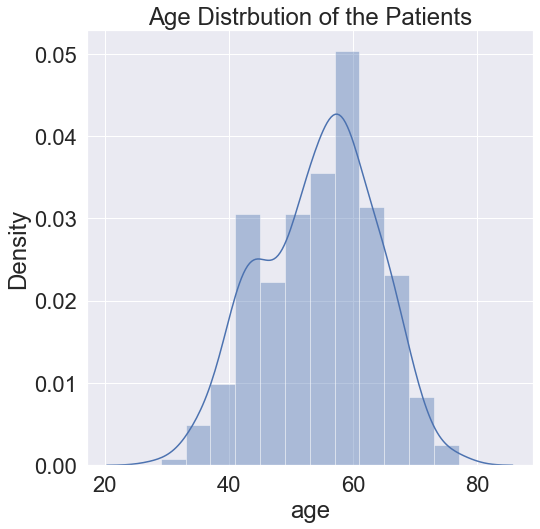

```python
# First, we will see the age distrbution of the patients.
plt.figure(figsize=(8,8))
plt.title('Age Distrbution of the Patients')
plt1 = sns.distplot(df_CD["age"])
```

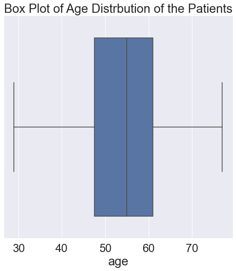

```python
plt.figure(figsize=(8,8))
plt.title('Box Plot of Age Distrbution of the Patients')
sns.boxplot(x=df_CD["age"])
```

```python
# Lets find out the heart attack chance by age group.
df_CD['age_group'] = pd.cut(df_CD['age'], 5)
print (df_CD[["age_group", "heart_attack"]].groupby(['age_group'], as_index=False).mean())
```

```
        age_group  heart_attack
0  (28.952, 38.6]      0.750000
1    (38.6, 48.2]      0.704225
2    (48.2, 57.8]      0.577320
3    (57.8, 67.4]      0.377358
4    (67.4, 77.0]      0.588235
```

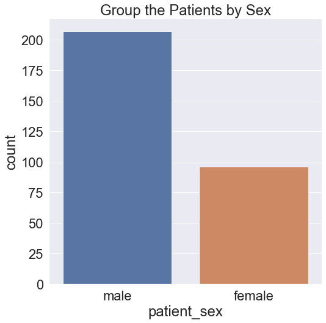

```python
# Now we want to see how sex affect the Cardiovascular Disease.
sex = { 0:"female", 1:"male" }
df_CD["patient_sex"] = df_CD["sex"].map(sex)
plt.figure(figsize=(8,8))
plt.title("Group the Patients by Sex")
plt2 = sns.countplot(x="patient_sex", data=df_CD)
```

```python
# See the risk of heart attack by sex.
print (df_CD[["sex", "heart_attack"]].groupby(['sex'], as_index=False).mean())
```

```
   sex  heart_attack
0    0      0.750000
1    1      0.449275
```

Hypothesis 2:

From the Group the Patients by Sex plot, we can see that there are about twice more male patients than female patients in the dataset. We can say that male is more likely to have Cardiovascular Disease comparing to female. On the other hand, female have much higher heart attack risk comparing to male. Thus, female patients should pay more attention avoid heart attack.

### Before we do the Heart Attack risk factor analysis, we will study each factor respectivly.

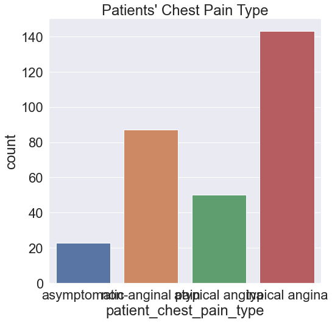

```python
# Studing the Chest Pain factor.
chest_pain = { 0:"typical angina", 1:"atypical angina", 2:"non-anginal pain", 3:"asymptomatic"}
df_CD["patient_chest_pain_type"] = df_CD["chest_pain_type"].map(chest_pain)
plt.figure(figsize=(8,8))
plt.title("Patients' Chest Pain Type")
plt3 = sns.countplot(x="patient_chest_pain_type", data=df_CD)
```

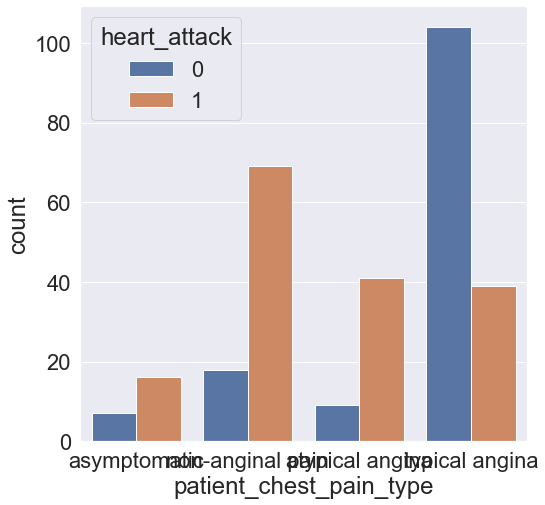

```python
plt.figure(figsize=(8,8))
plt4 = sns.countplot(x = "patient_chest_pain_type", hue = "heart_attack", data = df_CD)
```

```python
print (df_CD[["chest_pain_type", "heart_attack"]].groupby(['chest_pain_type'], as_index=False).mean())
# Clearly, most patients would have typical angina symptom,
# and atypical angina would have highest risk cause heart attack.
```

```
   chest_pain_type  heart_attack
0                0      0.272727
1                1      0.820000
2                2      0.793103
3                3      0.695652
```

Hypothesis 3:

From the Plots we can see that most Cardiovascular Disease patients would have different types of chest pain. Typical angina symptom is the most common chest pain type. Clearly, patients with chest pain would have largly higher risk to have heart attack. Atypical angina chest pain type is the most dangous type that could cause heart attack.

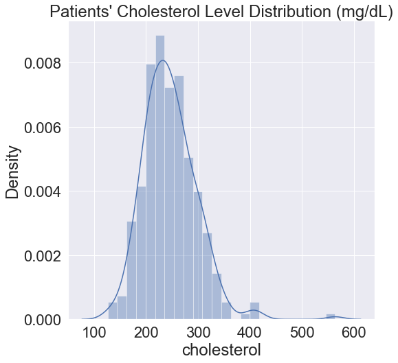

```python
# Study the Cholesterol Level.
plt.figure(figsize=(8,8))
plt.title("Patients' Cholesterol Level Distribution (mg/dL)")
plt5 = sns.distplot(df_CD["cholesterol"])
```

```python
df_CD['cholesterol_group'] = pd.cut(df_CD['cholesterol'], 5)
print (df_CD[["cholesterol_group", "heart_attack"]].groupby(['cholesterol_group'], as_index=False).mean())
```

```
  cholesterol_group  heart_attack
0  (125.562, 213.6]      0.611765
1    (213.6, 301.2]      0.514286
2    (301.2, 388.8]      0.526316
3    (388.8, 476.4]      0.500000
4    (476.4, 564.0]      1.000000
```

Hypothesis 4:

As we know, Cholesterol level higher than 200mg/dL would be considered high Cholesterol level. Since most patients have Cholesterol level higher than normal, peak at around 250mg/dL, we can say that the higher Cholesterol level would increase the risk of Cardiovascular Disease. From the Cholesterol group cause heart attack risk relationship, we can see there is no obvious evidence showing that high Colesterol level would increase heart attack risk. The group of 476-564mg/dL would be considered as outlier since the sample size in this group is small.

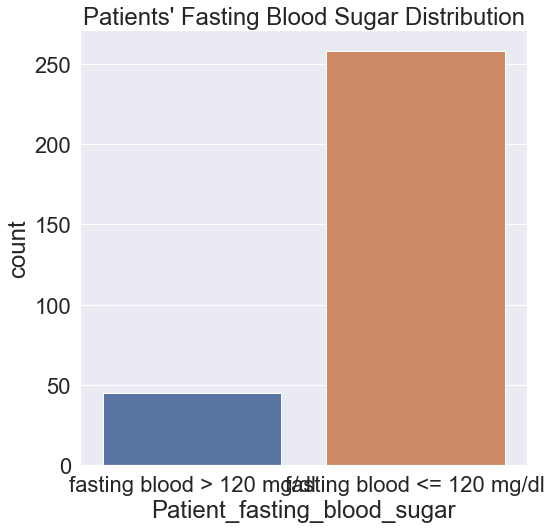

```python
# Studing the blood sugar factor.
fasting_blood_sugar = { 0: "fasting blood <= 120 mg/dl", 1: "fasting blood > 120 mg/dl"}
df_CD["Patient_fasting_blood_sugar"] = df_CD["fasting_blood_sugar"].map(fasting_blood_sugar)
plt.figure(figsize=(8,8))
plt.title("Patients' Fasting Blood Sugar Distribution")
plt6 = sns.countplot(x = "Patient_fasting_blood_sugar", data = df_CD)
```

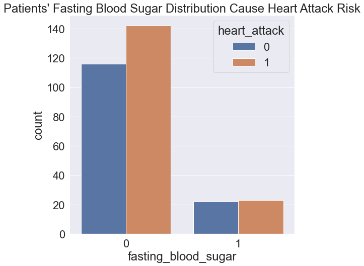

```python
plt.figure(figsize=(8,8))
plt.title("Patients' Fasting Blood Sugar Distribution Cause Heart Attack Risk")
plt6_1 = sns.countplot(x = "fasting_blood_sugar", hue = "heart_attack", data = df_CD)
```

```python
print (df_CD[["fasting_blood_sugar", "heart_attack"]].groupby(['fasting_blood_sugar'], as_index=False).mean())
# No obvious evidence showing that high fasting blood surgar level would increase heart attack risk.
```

```
   fasting_blood_sugar  heart_attack
0                    0      0.550388
1                    1      0.511111
```

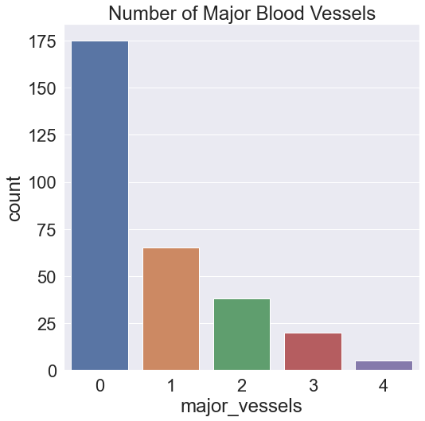

```python
# Study the number of major blood vessels.
plt.figure(figsize=(8,8))
plt.title("Number of Major Blood Vessels")
plt7 = sns.countplot(x = "major_vessels", data = df_CD)
```

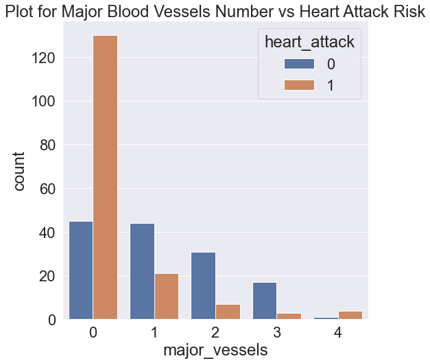

```python
plt.figure(figsize=(8,8))
plt.title("Plot for Major Blood Vessels Number vs Heart Attack Risk")
sns.countplot(x="major_vessels", hue="heart_attack", data=df_CD)
```

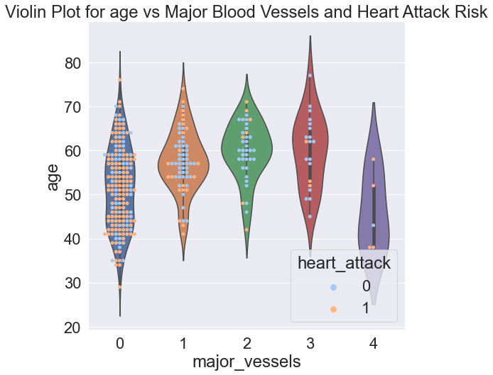

```python
plt.figure(figsize = (8,8))
plt.title("Violin Plot for age vs Major Blood Vessels and Heart Attack Risk")
sns.violinplot(x='major_vessels',y='age',data=df_CD)
sns.swarmplot(x=df_CD['major_vessels'],y=df_CD['age'],hue=df_CD['heart_attack'], palette='pastel')
# From this violin plot, we can see that with major vessels number of 0,
# patients would have higher risk having heart attack.
# Patients with 1-3 major vessels number have comparely lower heart attack risk.
```

### Now, lets see the overview of the dataset.

```python
df_CD.describe()
```

|  | age | sex | chest_pain_type | resting_blood_pressure | cholesterol | fasting_blood_sugar | resting_ecg | max_heartrate | exercise_angina | st_depression | st_slope | major_vessels | thalassemia | heart_attack |
| --- | --- | --- | --- | --- | --- | --- | --- | --- | --- | --- | --- | --- | --- | --- |
| count | 303.000000 | 303.000000 | 303.000000 | 303.000000 | 303.000000 | 303.000000 | 303.000000 | 303.000000 | 303.000000 | 303.000000 | 303.000000 | 303.000000 | 303.000000 | 303.000000 |
| mean | 54.366337 | 0.683168 | 0.966997 | 131.623762 | 246.264026 | 0.148515 | 0.528053 | 149.646865 | 0.326733 | 1.039604 | 1.399340 | 0.729373 | 2.313531 | 0.544554 |
| std | 9.082101 | 0.466011 | 1.032052 | 17.538143 | 51.830751 | 0.356198 | 0.525860 | 22.905161 | 0.469794 | 1.161075 | 0.616226 | 1.022606 | 0.612277 | 0.498835 |
| min | 29.000000 | 0.000000 | 0.000000 | 94.000000 | 126.000000 | 0.000000 | 0.000000 | 71.000000 | 0.000000 | 0.000000 | 0.000000 | 0.000000 | 0.000000 | 0.000000 |
| 25% | 47.500000 | 0.000000 | 0.000000 | 120.000000 | 211.000000 | 0.000000 | 0.000000 | 133.500000 | 0.000000 | 0.000000 | 1.000000 | 0.000000 | 2.000000 | 0.000000 |
| 50% | 55.000000 | 1.000000 | 1.000000 | 130.000000 | 240.000000 | 0.000000 | 1.000000 | 153.000000 | 0.000000 | 0.800000 | 1.000000 | 0.000000 | 2.000000 | 1.000000 |
| 75% | 61.000000 | 1.000000 | 2.000000 | 140.000000 | 274.500000 | 0.000000 | 1.000000 | 166.000000 | 1.000000 | 1.600000 | 2.000000 | 1.000000 | 3.000000 | 1.000000 |
| max | 77.000000 | 1.000000 | 3.000000 | 200.000000 | 564.000000 | 1.000000 | 2.000000 | 202.000000 | 1.000000 | 6.200000 | 2.000000 | 4.000000 | 3.000000 | 1.000000 |

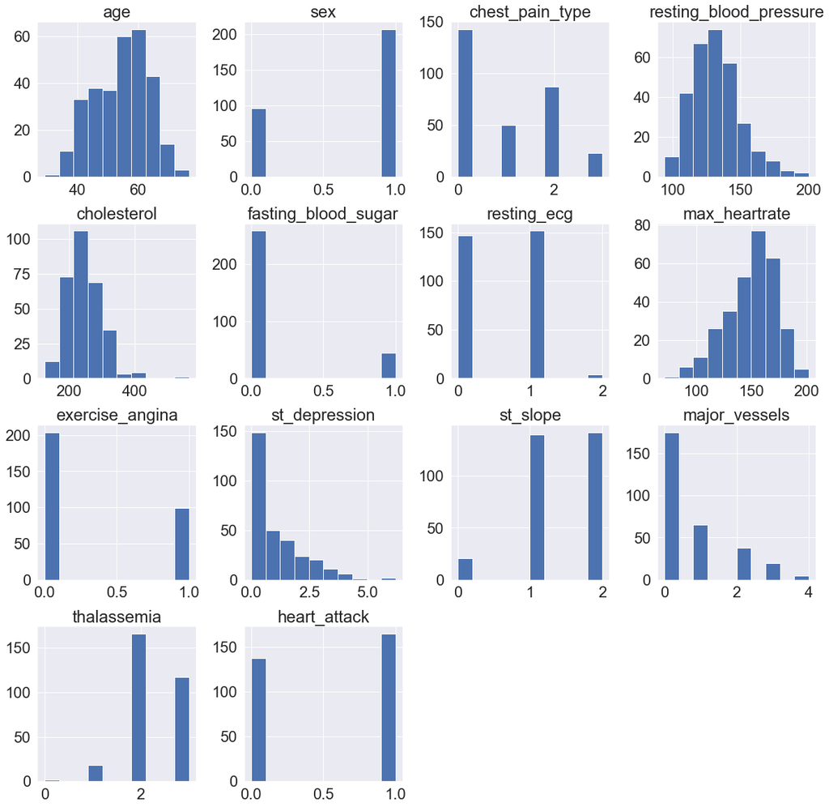

```python
# Display the overall data distribution.
fig = plt.figure(figsize = (20,20))
plots = fig.gca()
df_CD.hist(ax = plots)
plt.show()
```

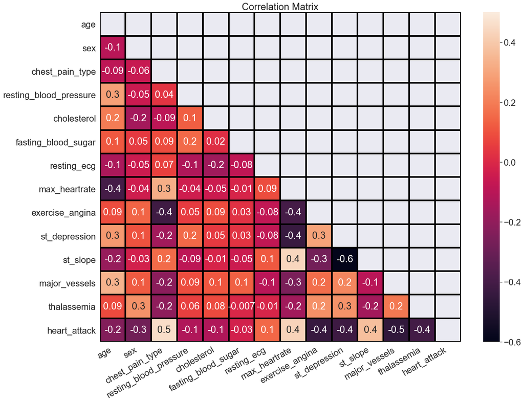

```python
# Lets create the Correlation Matrix.
plt.subplots(figsize = (20,15))
mask = np.triu(np.ones_like(df_CD.corr(), dtype = np.bool))
corr_matrix = sns.heatmap(df_CD.corr("spearman"), mask = mask, annot = True, linewidths=3, linecolor='black', fmt = '.1g', vmin = -.6, vmax = 0.5)

corr_matrix.set_xticklabels(corr_matrix.get_xticklabels(), rotation=30, horizontalalignment='right')
corr_matrix.set_title("Correlation Matrix")
```

### Correlation Analysis

From the correlation matrix we can see the correlation value between each variable provided in the dataset. We can see how each variable correlated with other variables by the color(heat map style) and the value. First, we can see how each health factors affect the heart attack risk.

- Heart Attack vs Chest Pain - **0.5**
- Heart Attack vs Maximum Heart Rate - **0.4**
- Heart Attack vs peak exercise ST segment slop - **0.4**

Besides, there are some other interesting founds in this matrix.

- Major Vessels Number vs Age - **0.3**
- Thalassemia vs Sex - **0.3**
- Chest Pain vs Maximum Heart Rate - **0.3**
- Resting Blood Presure vs Age - **0.3** The above variables are also have relatively high correlated. We can do the further studies based on those founds.

### Machine Learning Prediction

With given patient's age, sex, chest pain type, resting blood pressure, cholesterol level, can we predict if the patient is going to have heart attack risk?

```python
from sklearn.linear_model import LogisticRegression
from sklearn.metrics import classification_report
import random
# Implement the logistic regression model.
LG_model = LogisticRegression(solver='liblinear', random_state=0)
# Adding patient's age, sex, chest pain type, resting blood pressure, cholesterol level as given varaibles.
x = np.dstack((df_CD['sex'],df_CD['age'],df_CD['chest_pain_type'],df_CD['resting_blood_pressure'], df_CD['cholesterol']))[0]
# Predict if the patient is going to have heart attack risk.
y = np.array(df_CD['heart_attack'])
LG_model.fit(x,y)
print("Model Intercepts: ", LG_model.intercept_, "\nModel Coefs: ", LG_model.coef_)
y_pred = LG_model.predict(x)
LG_report = classification_report(y, y_pred)
print("Report: \n", LG_report)
```

```
Model Intercepts:  [2.42226128]
Model Coefs:  [[-1.27402179e+00 -3.33713545e-02  1.00472986e+00 -3.97650100e-03
   1.77192160e-04]]
Report:
               precision    recall  f1-score   support

           0       0.73      0.76      0.74       138
           1       0.79      0.76      0.78       165

    accuracy                           0.76       303
   macro avg       0.76      0.76      0.76       303
weighted avg       0.76      0.76      0.76       303
```

```python
# Set a list of patient examples.
predict_sample = [[0, 20, 0, 100, 100]]
for i in range(50):
    predict_sample.append([random.randint(0, 1),random.randint(20, 90),random.randint(0, 3), random.randint(100, 200), random.randint(100, 500)])
predict_sample.append([1, 90, 3, 200, 500])
print("Samples' factor: [age, sex, chest pain type, resting blood pressure, cholesterol level] \n",predict_sample)
print("\nSamples' Heart Attack Risk: \n", model.predict(predict_sample))
```

[output not shown]

### Conclusion

In this project, we have analyzed the Cardiovascular Disease dataset, and studied how different health factors would have affect on Cardiovascular Disease, and cause heart attack. We have used different plots to visulized the result, and analyzed the hypothesis we made.

In this project we have used the typical data analysis structure, which follows data mining - data processing - hypothesis testing - Machine Learning.

Here are the hypothesis we have proved and the machine learning prediction result:

- The elder patients would have higher chance to have Cardiovascular Disease.

Yes, according to the age distribution of the dataset, we can say that the people at age of 60 would have higher chance to have Cardiovascular Disease. Besides, for the overview, we can see age range from 40 to 70 is a high Cardiovascular Disease risk age range. From the plot result, we can see that age group of 28-39 have the highest heart attack risk, following by age group 39-48. The plot shows that younger Cardiovascular Disease patients would have slightly higher heart attack risk comparing to patients 48 years elder. However, from the correlation analysis, the age does not relate to heart attack risk obviously.

- Patients with chest pain symptom would have higher chance have heart attack.

Yes. From the Plots we can see that most Cardiovascular Disease patients would have different types of chest pain. Typical angina symptom is the most common chest pain type. Clearly, patients with chest pain would have largly higher risk to have heart attack. Atypical angina chest pain type is the most dangous type that could cause heart attack. Besides, the correlation analysis has proved that the chest pain is high related to the heart attack risk.

- Patients with high cholestoral level would have higher chance have heart attack.

No. Cholesterol level higher than 200mg/dL would be considered high Cholesterol level. Since most patients have Cholesterol level higher than normal, peak at around 250mg/dL, we can say that the higher Cholesterol level would increase the risk of Cardiovascular Disease. From the Cholesterol group cause heart attack risk relationship, we can see there is no obvious evidence showing that high Colesterol level would increase heart attack risk. Besides, the correlation analysis has proved that the Cholesterol level does not related to the heart attack risk.

- With given patient's age, sex, chest pain type, resting blood pressure, cholesterol level, predict if the patient is going to have heart attack risk.

In the Machine Learning prediction part, I have used the logistic regression model to generate the prediction. I have randomly generated 50 samples, and made the heart attack risk predictions for those samples. For example, a patient who is female, age of 20, has typical angina, with resting blood pressure of 100, and cholesterol level of 100 would likely to have heart attack risk.